# Práctico 4

Ejercicio 2

> Los datos en el archivo `melanoma.txt` corresponden al número de casos de melanoma registrados en Estados Unidos en el período 1969-1991 en hombres blancos clasificados por edad y región (`0 = Norte`, `1 = Sur`). La última columna es el tamaño de la población registrada en el censo de EE.UU.

## Parte a

> Codifique la variable categórica `edad`, tomando el grupo de menor edad como referencia.

```r
melanoma <- readr::read_delim(
  file = here::here("03_glm/melanoma.txt"),
  delim = "\t",
  col_types = "cccc"
) %>%
  dplyr::rename(
    region = base::names(.)[1],
    edad = Edad,
    casos = Casos,
    pop = base::names(.)[4]
  ) %>%
  dplyr::mutate(
    region = forcats::as_factor(base::as.integer(region)),
    casos = base::as.integer(casos),
    pop = base::as.integer(pop)
  ) %>%
  dplyr::group_by(
    region
  ) %>%
  dplyr::mutate(
    edad = dplyr::row_number() - 1,
    edad = forcats::as_factor(edad)
  ) %>%
  dplyr::ungroup()
```

```r
melanoma
```

```
# A tibble: 12 x 4
   region edad  casos     pop
   <fct>  <fct> <int>   <int>
 1 0      0        61 2880262
 2 0      1        76  564535
 3 0      2        98  592983
 4 0      3       104  450740
 5 0      4        63  270908
 6 0      5        80  161850
 7 1      0        64 1074246
 8 1      1        75  220407
 9 1      2        68  198119
10 1      3        63  134084
11 1      4        45   70708
12 1      5        27   34233
```

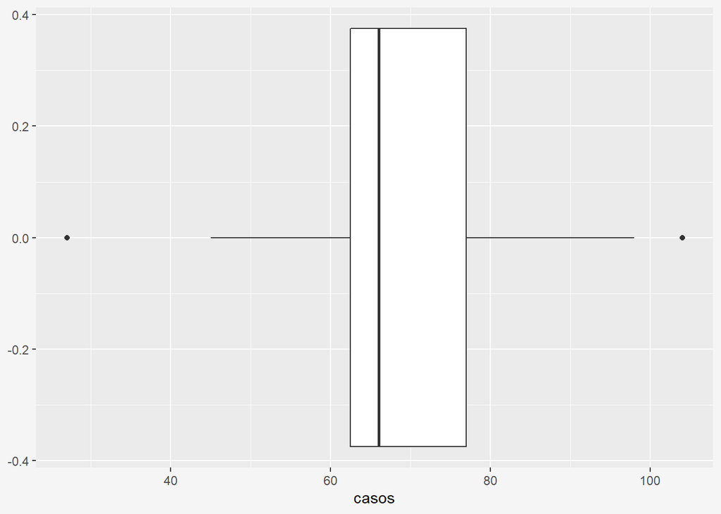

```r
melanoma %>%
  ggplot2::ggplot(
    ggplot2::aes(
      x = casos
    )
  ) +
  ggplot2::geom_boxplot() +
  ggplot2::theme(
    plot.background = ggplot2::element_rect(
      fill = "#F5F5F5",
      color = "#F5F5F5"
    ),
    legend.background = ggplot2::element_rect(
      fill = "#F5F5F5",
      color = "#F5F5F5"
    )
  )
```

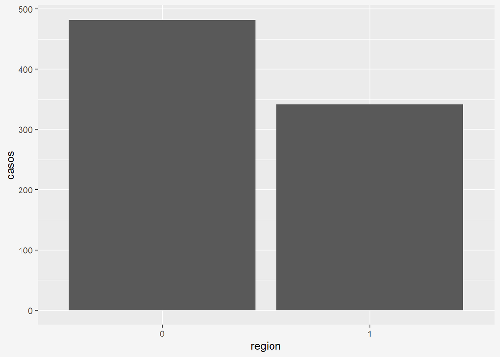

```r
melanoma %>%
  dplyr::group_by(
    region
  ) %>%
  dplyr::summarise(
    dplyr::across(
      .cols = casos:pop,
      .fns = ~base::sum(.x, na.rm = TRUE)
    ),
    .groups = "drop"
  ) %>%
  ggplot2::ggplot(
    ggplot2::aes(
      x = region,
      y = casos
    )
  ) +
  ggplot2::geom_col() +
  ggplot2::theme(
    plot.background = ggplot2::element_rect(
      fill = "#F5F5F5",
      color = "#F5F5F5"
    ),
    legend.background = ggplot2::element_rect(
      fill = "#F5F5F5",
      color = "#F5F5F5"
    )
  )
```

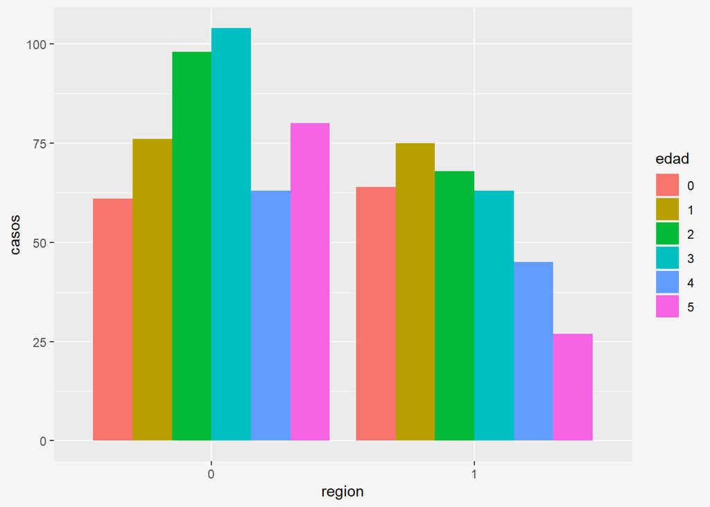

```r
melanoma %>%
  ggplot2::ggplot(
    ggplot2::aes(
      x = region,
      y = casos,
      fill = edad
    )
  ) +
  ggplot2::geom_col(
    position = "dodge"
  ) +
  ggplot2::theme(
    plot.background = ggplot2::element_rect(
      fill = "#F5F5F5",
      color = "#F5F5F5"
    ),
    legend.background = ggplot2::element_rect(
      fill = "#F5F5F5",
      color = "#F5F5F5"
    )
  )
```

## Parte b

> Construya un modelo de regresión de Poisson para estudiar la relación entre el número de casos de melanoma, la edad y la región, considerando la variable `Pop` como *offset*.

```r
base::summary(
  poisson_fit <- stats::glm(
    formula = casos ~ edad + region,
    data = melanoma,
    family = stats::poisson(link = "log"),
    offset = base::log(pop)
  )
)
```

```
Call:
stats::glm(formula = casos ~ edad + region, family = stats::poisson(link = "log"),
    data = melanoma, offset = base::log(pop))

Deviance Residuals:
      1        2        3        4        5        6        7        8
-0.8283  -0.4581   0.3667   0.4279  -0.5932   0.8904   0.8686   0.4780
      9       10       11       12
-0.4273  -0.5302   0.7469  -1.3610

Coefficients:
             Estimate Std. Error z value Pr(>|z|)
(Intercept) -10.65831    0.09518 -111.97   <2e-16 ***
edad1         1.79737    0.12093   14.86   <2e-16 ***
edad2         1.91309    0.11844   16.15   <2e-16 ***
edad3         2.24180    0.11834   18.94   <2e-16 ***
edad4         2.36572    0.13152   17.99   <2e-16 ***
edad5         2.94468    0.13205   22.30   <2e-16 ***
region1       0.81948    0.07103   11.54   <2e-16 ***
---
Signif. codes:  0 '***' 0.001 '**' 0.01 '*' 0.05 '.' 0.1 ' ' 1

(Dispersion parameter for poisson family taken to be 1)

    Null deviance: 895.8197  on 11  degrees of freedom
Residual deviance:   6.2149  on  5  degrees of freedom
AIC: 92.44

Number of Fisher Scoring iterations: 4
```

```r
poisson_fit[["deviance"]] / poisson_fit[["df.residual"]]
```

```
[1] 1.242979
```

## Parte c

> Interprete la salida del modelo.

**Bondad de ajuste**

La desvianza resudial es la diferencia entre la desvianza del modelo estimado y la máxima desvianza del modelo ideal donde los valores predichos son iguales a los observados. Por lo tanto, si la diferencia es suficientemente pequeña, entonces la Bondad de ajuste no será significativa, indicando que el modelo se ajusta a los datos.

```r
stats::pchisq(poisson_fit[["deviance"]], poisson_fit[["df.residual"]], lower.tail = FALSE)
```

```
[1] 0.2858666
```

**Significación de la region**

Para testear la significancia de la region podemos comparar la devianza del modelo completo con la desvianza del modelo que excluye la variable `region`.

```r
base::summary(reg_sig <- stats::update(poisson_fit, . ~ . - region))
```

```
Call:
stats::glm(formula = casos ~ edad, family = stats::poisson(link = "log"),
    data = melanoma, offset = base::log(pop))

Deviance Residuals:
    Min       1Q   Median       3Q      Max
-3.3512  -2.4883   0.4518   3.8640   4.5869

Coefficients:
             Estimate Std. Error z value Pr(>|z|)
(Intercept) -10.36205    0.08944 -115.85   <2e-16 ***
edad1         1.80597    0.12092   14.94   <2e-16 ***
edad2         1.89286    0.11842   15.98   <2e-16 ***
edad3         2.20098    0.11827   18.61   <2e-16 ***
edad4         2.30274    0.13137   17.53   <2e-16 ***
edad5         2.84859    0.13170   21.63   <2e-16 ***
---
Signif. codes:  0 '***' 0.001 '**' 0.01 '*' 0.05 '.' 0.1 ' ' 1

(Dispersion parameter for poisson family taken to be 1)

    Null deviance: 895.82  on 11  degrees of freedom
Residual deviance: 130.44  on  6  degrees of freedom
AIC: 214.66

Number of Fisher Scoring iterations: 4
```

```r
stats::anova(poisson_fit, reg_sig, test = "Chisq")
```

```
Analysis of Deviance Table

Model 1: casos ~ edad + region
Model 2: casos ~ edad
  Resid. Df Resid. Dev Df Deviance  Pr(>Chi)
1         5      6.215
2         6    130.435 -1  -124.22 < 2.2e-16 ***
---
Signif. codes:  0 '***' 0.001 '**' 0.01 '*' 0.05 '.' 0.1 ' ' 1
```

**Interpretación de los coeficientes**

```r
base::exp(stats::coef(poisson_fit))
```

```
 (Intercept)        edad1        edad2        edad3        edad4        edad5
2.350472e-05 6.033788e+00 6.773973e+00 9.410278e+00 1.065175e+01 1.900457e+01
     region1
2.269330e+00
```

**Fitted values**

```r
stats::predict(poisson_fit, type = "response")
```

```
       1        2        3        4        5        6        7        8
67.69975 80.06376 94.41495 99.69736 67.82626 72.29791 57.30025 70.93624
       9       10       11       12
71.58505 67.30264 40.17374 34.70209
```

**Media marginal esperada para la población**

```r
new <- tibble::tibble(
  region = melanoma[["region"]],
  edad = melanoma[["edad"]],
  pop = base::mean(melanoma[["pop"]])
)
stats::predict(
  object = poisson_fit,
  newdata = new,
  type = "response",
  se.fit = TRUE
)
```

```
$fit
        1         2         3         4         5         6         7         8
 13.03156  78.62964  88.27540 122.63056 138.80887 247.65906  29.57290 178.43660
        9        10        11        12
200.32602 278.28920 315.00312 562.02010

$se.fit
        1         2         3         4         5         6         7         8
 1.240404  6.915784  7.365723 10.117885 13.851236 24.612422  2.879349 16.000544
        9        10        11        12
17.528366 24.555827 33.409711 60.659261

$residual.scale
[1] 1
```

## Parte d

> Realice un gráfico en donde en el eje $x$ se presenten los residuos del modelo y en el eje $y$ los valores ajustados por el modelo. Interprete.

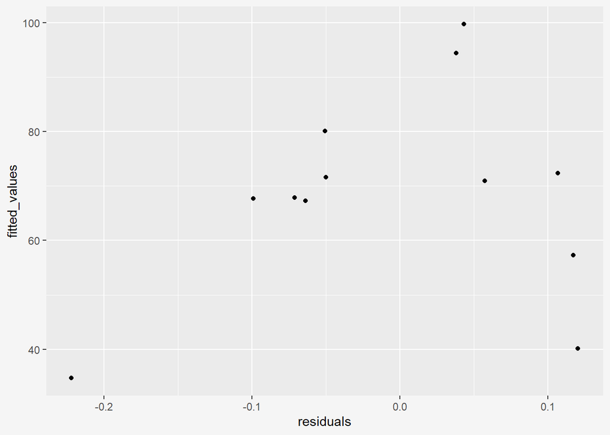

```r
tibble::tibble(
  residuals = poisson_fit[["residuals"]],
  fitted_values = poisson_fit[["fitted.values"]]
) %>%
  ggplot2::ggplot(
    ggplot2::aes(
      x = residuals,
      y = fitted_values
    )
  ) +
  ggplot2::geom_point() +
  ggplot2::theme(
    plot.background = ggplot2::element_rect(
      fill = "#F5F5F5",
      color = "#F5F5F5"
    )
  )
```

## Parte e

> Realice un gráfico en donde en el eje $x$ se presenten los valores observados y en el eje $y$ los valores ajustados por el modelo. Interprete.

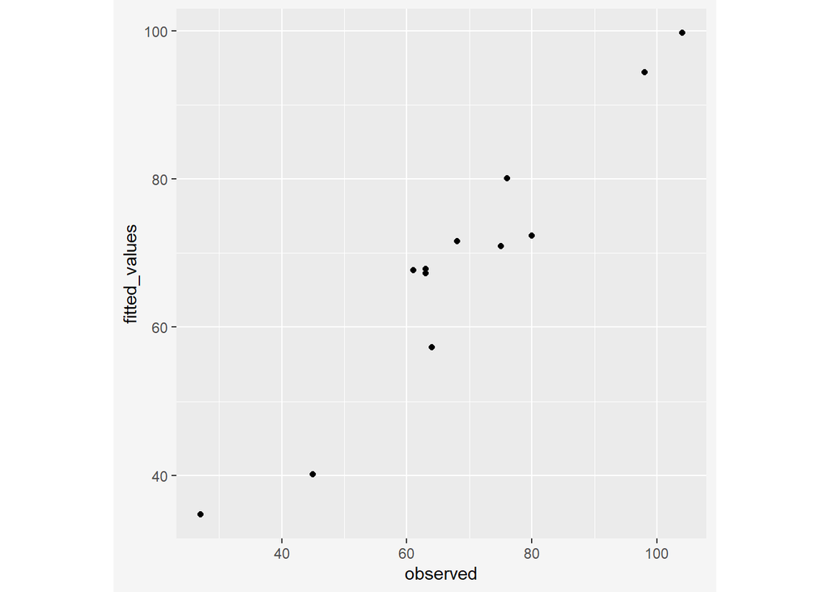

```r
tibble::tibble(
  observed = melanoma[["casos"]],
  fitted_values = poisson_fit[["fitted.values"]]
) %>%
  ggplot2::ggplot(
    ggplot2::aes(
      x = observed,
      y = fitted_values
    )
  ) +
  ggplot2::geom_point() +
  ggplot2::theme(
    aspect.ratio = 1,
    plot.background = ggplot2::element_rect(
      fill = "#F5F5F5",
      color = "#F5F5F5"
    )
  )
```

## Extra - Negative Binomial

```r
dplyr::summarise(
  melanoma,
  mean = base::mean(casos, na.rm = TRUE),
  var = stats::var(casos, na.rm = TRUE),
  .groups = "drop"
)
```

```
# A tibble: 1 x 2
   mean   var
  <dbl> <dbl>
1  68.7  434.
```

```r
base::summary(
  nb_fit <- MASS::glm.nb(
    formula = casos ~ edad + region,
    data = melanoma,
    link = log
  )
)
```

```
Call:
MASS::glm.nb(formula = casos ~ edad + region, data = melanoma,
    link = log, init.theta = 84.74877259)

Deviance Residuals:
       1         2         3         4         5         6         7         8
-1.19254  -1.06136   0.04386   0.44872  -0.03946   1.68860   1.20003   1.07208
       9        10        11        12
-0.04813  -0.50919   0.04380  -2.21369

Coefficients:
            Estimate Std. Error z value Pr(>|z|)
(Intercept)  4.31019    0.12533  34.390  < 2e-16 ***
edad1        0.18806    0.16252   1.157 0.247199
edad2        0.26827    0.16095   1.667 0.095552 .
edad3        0.26860    0.16094   1.669 0.095129 .
edad4       -0.16049    0.17073  -0.940 0.347216
edad5       -0.19210    0.17161  -1.119 0.262959
region1     -0.35112    0.09494  -3.698 0.000217 ***
---
Signif. codes:  0 '***' 0.001 '**' 0.01 '*' 0.05 '.' 0.1 ' ' 1

(Dispersion parameter for Negative Binomial(84.7488) family taken to be 1)

    Null deviance: 42.640  on 11  degrees of freedom
Residual deviance: 13.358  on  5  degrees of freedom
AIC: 108.61

Number of Fisher Scoring iterations: 1

              Theta:  84.7
          Std. Err.:  86.1

 2 x log-likelihood:  -92.609
```

```r
pscl::odTest(nb_fit)
```

```
Likelihood ratio test of H0: Poisson, as restricted NB model:
n.b., the distribution of the test-statistic under H0 is non-standard
e.g., see help(odTest) for details/references

Critical value of test statistic at the alpha= 0.05 level: 2.7055
Chi-Square Test Statistic =  1.8747 p-value = 0.08547
```

```r
AER::dispersiontest(poisson_fit)
```

```
    Overdispersion test

data:  poisson_fit
z = -3.3547, p-value = 0.9996
alternative hypothesis: true dispersion is greater than 1
sample estimates:
dispersion
 0.5158269
```